# Power of R

2022-06-30

## Demonstrated through three data analytics projects

Load Libraries

```r
library(tidyverse)
library(knitr)
library(igraph)
library(networkD3)
library(visNetwork)
library(tidytext) #install.packages("tidytext")
library(wordcloud) #install.packages("wordcloud")
library(ggtext)
library(ggalt)
library(ggthemes)
library(ggpubr)
```

## 1.Sentiment Analysis through Word Cloud

Data Source: [Indian Budget Portal](https://www.indiabudget.gov.in/)

Load data

reshape the .txt data frame into one column

```r
tidy_dat <- dat %>%
  pivot_longer(everything(), values_to = 'word', names_to = NULL)
```

Tokenize

```r
tokens <- tidy_dat %>%
  unnest_tokens(word, word) %>%
  count(word, sort = TRUE)
```

Load default stop words

```r
data("stop_words")
```

Remove stop words using dplyr::anti_join

```r
tokens_clean <- tokens %>%
  anti_join(stop_words, by='word') %>%
  # remove numbers
  filter(!str_detect(word, "^[0-9]"))
```

Remove additional words seen in first round

```r
uni_sw <- data.frame(word = c("cent", "pm", "crore",
                              "lakh", "set",
                              "level", "sir"))

tokens_clean <- tokens_clean %>%
  anti_join(uni_sw, by = "word")
```

Plot

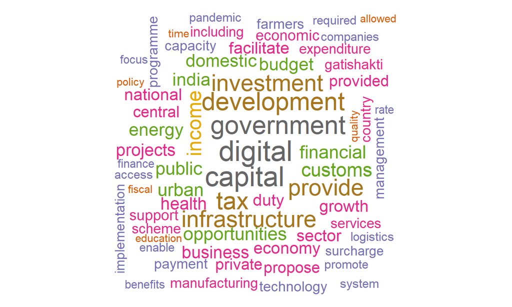

## 2.Customisation available in R visualisation

Customisation at micro level, e.g. adding icons, country flags, etc. in Axes of Plots generated.

Data Set used- 120 Years of Olympics Source: [Kaggle](https://www.kaggle.com/datasets/heesoo37/120-years-of-olympic-history-athletes-and-results)

## Output plot

[figure not shown]

## 3. Network Analysis and Visualisation

Data Set - Export Schemes data sample

A beneficiary is entitled to get only one Import/Export Code. However network analysis revealed that a single beneficiary was enrolled using different attributes such as mobile number, email, PAN, bank account number, etc. and obtained multiple IECs.

Data points analysed

- Unique IE Code
- Other Identification attributes, such as
  - Mobile number
  - E-mail
  - PAN Number

Code Explanation: Steps-

1. Load data.
2. Convert all attributes to tidy format, using `tidyr::pivot_longer()`
3. Convert it to graph object, using `igraph` library.
4. Add attributes(color and shape) for each node
5. Plot interactive plot using `visNetwork` library.

## Preview the data

| IE_code | telephone | email | PAN |
| --- | --- | --- | --- |
| 8629664493 | 9870029885 | goldenstars0786@gmail.com | AABCT0050D |
| 8849905875 | 9740516000 | grsisl@rediffmail.com | AABCT0050D |
| 8186529510 | 9570698755 | bindalk19@gmail.com | AAEFK6698Q |
| 8797183238 | 9670553990 | bh2cc@yahoo.co.in | AAFCR9606R |
| 8118229673 | 9870029885 | lozicnet_delhi@goodboss.com | AAKPG2765Q |
| 8186821161 | 9870029885 | scientific.syndicate@rediffmail.com | ACCPC3990P |
| 8610077392 | 9709244730 | goelk19@gmail.com | AJGPR3543Q |
| 8651507473 | 9740516885 | bh26007@yahoo.co.in | AJGPR3543Q |
| 8794363860 | 9570698755 | abcdrsisl@rediffmail.com | AJOPT5146K |
| 8559625141 | 9740516885 | grsisl@rediffmail.com | GANPS2679C |

## Performing network analysis

[interactive chart not shown]

Plot the object

[figure not shown]

## Features of R used -

- Level of customisation available
- Better readable and concise code
- Interactive visualisations
- Tidy data concepts laid down by Hadley Wickham, widely used across many programming languages such as pandas in python, tableau, etc.
- Functional programming aspects of `dplyr::across` - a powerful function to perform large number of analysis in one single line of code.
- Network Analysis, Word Cloud, etc. otherwise not possible in many licensed softwares such as Tableau and Power BI, without knowledge of R/Python.